# Prediction Assignment

Oleksandr Myronov

29 06 2021

This Prediction Assignment is based on [Weight Lifting Exercises dataset](https://d396qusza40orc.cloudfront.net/predmachlearn/pml-training.csv), description for this data can be found [here](http://web.archive.org/web/20161224072740/http:/groupware.les.inf.puc-rio.br/har). The goal of this study is prediction of manner in which people do exercises (barbell lifts).

## Loading and preprocessing data

Original data have 160 columns, some of them have NA-s, so we should perform some data cleaning. In this study we just remove columns with NA-s to make data suitable for machine learning algorithms.

```r
library(ggplot2)      #Loading libraries
library(dplyr)
library(caret)
library(e1071)
library(klaR)
download.file("https://d396qusza40orc.cloudfront.net/predmachlearn/pml-training.csv",
              "pml-training.csv")
read.csv("pml-training.csv", header=T,       #reading .csv file
         na.strings = c("NA", "")) %>%       #reading empty strings as NA-s
mutate(classe=factor(classe)) -> HARdata     #factorizing output variable

notNAcols<-apply(is.na(HARdata), 2, sum)==0  #finding columns without NA-s
HARdata<-HARdata[,notNAcols]                 #removing NA-s
HARdata<-HARdata[,-c(1:7)]                   #removing timestamps and index
set.seed(234837)
inTraining<-createDataPartition(HARdata$classe, p=0.75, list=F)
trainset<-HARdata[inTraining,]               #creating training set
crossval<-HARdata[-inTraining,]              #creating cross-validation set
dim(trainset)                                #printing training set dimensions
```

```
## [1] 14718    53
```

## Removing highly-correlated predictors

```r
highlyCorrelated<-findCorrelation(cor(select(trainset,-classe)), cutoff = .75)
trainset2<-trainset[,-highlyCorrelated]
dim(trainset2)
```

```
## [1] 14718    32
```

Now we reduced number of columns from 53 to 32.

## Fitting models

In this study we wouldn’t use cross-validation for tuning single model, it is computationally expensive and we have no guarantee, that single algorithm (even perfectly tuned) would be the best choice. Instead, we would apply some machine learning algorithms and use cross-validation for comparing the results and model selection.

### Support Vector Machine

First, we would train SVM with default radial basis and other default settings

```r
fitsvm<-svm(classe~., data=trainset2)
confusionMatrix(predict(fitsvm, newdata=crossval), crossval$classe)
```

```
## Confusion Matrix and Statistics
##
##           Reference
## Prediction    A    B    C    D    E
##          A 1388   57    4    2    0
##          B    2  866   26    1    1
##          C    2   24  806   74   19
##          D    0    2   16  722   26
##          E    3    0    3    5  855
##
## Overall Statistics
##
##                Accuracy : 0.9456
##                  95% CI : (0.9388, 0.9517)
##     No Information Rate : 0.2845
##     P-Value [Acc > NIR] : < 2.2e-16
##
##                   Kappa : 0.931
##
##  Mcnemar's Test P-Value : < 2.2e-16
##
## Statistics by Class:
##
##                      Class: A Class: B Class: C Class: D Class: E
## Sensitivity            0.9950   0.9125   0.9427   0.8980   0.9489
## Specificity            0.9820   0.9924   0.9706   0.9893   0.9973
## Pos Pred Value         0.9566   0.9665   0.8714   0.9426   0.9873
## Neg Pred Value         0.9980   0.9793   0.9877   0.9802   0.9886
## Prevalence             0.2845   0.1935   0.1743   0.1639   0.1837
## Detection Rate         0.2830   0.1766   0.1644   0.1472   0.1743
## Detection Prevalence   0.2959   0.1827   0.1886   0.1562   0.1766
## Balanced Accuracy      0.9885   0.9525   0.9567   0.9436   0.9731
```

SVM is doing not perfect, but quite well. This is the fastest method in compare with others in our study.

### Generelized Boosted Regression

Our second model would be GBM with different number of interactions and number of trees:

```r
gbmGrid <-  expand.grid(interaction.depth = c(1, 3, 5, 7),
                        n.trees=(1:10)*20,
                        shrinkage = 0.1,
                        n.minobsinnode = 20)
set.seed(564234)
fitGbm<-train(classe~., data=trainset2, method="gbm", verbose=F, tuneGrid = gbmGrid)
confusionMatrix(predict(fitGbm, newdata=crossval), crossval$classe)
```

```
## Confusion Matrix and Statistics
##
##           Reference
## Prediction    A    B    C    D    E
##          A 1391    8    1    0    0
##          B    3  927    8    1    0
##          C    1   14  834   17    0
##          D    0    0   12  783    4
##          E    0    0    0    3  897
##
## Overall Statistics
##
##                Accuracy : 0.9853
##                  95% CI : (0.9815, 0.9885)
##     No Information Rate : 0.2845
##     P-Value [Acc > NIR] : < 2.2e-16
##
##                   Kappa : 0.9814
##
##  Mcnemar's Test P-Value : NA
##
## Statistics by Class:
##
##                      Class: A Class: B Class: C Class: D Class: E
## Sensitivity            0.9971   0.9768   0.9754   0.9739   0.9956
## Specificity            0.9974   0.9970   0.9921   0.9961   0.9993
## Pos Pred Value         0.9936   0.9872   0.9630   0.9800   0.9967
## Neg Pred Value         0.9989   0.9945   0.9948   0.9949   0.9990
## Prevalence             0.2845   0.1935   0.1743   0.1639   0.1837
## Detection Rate         0.2836   0.1890   0.1701   0.1597   0.1829
## Detection Prevalence   0.2855   0.1915   0.1766   0.1629   0.1835
## Balanced Accuracy      0.9973   0.9869   0.9838   0.9850   0.9974
```

Plot for GBM accuracy on training set:

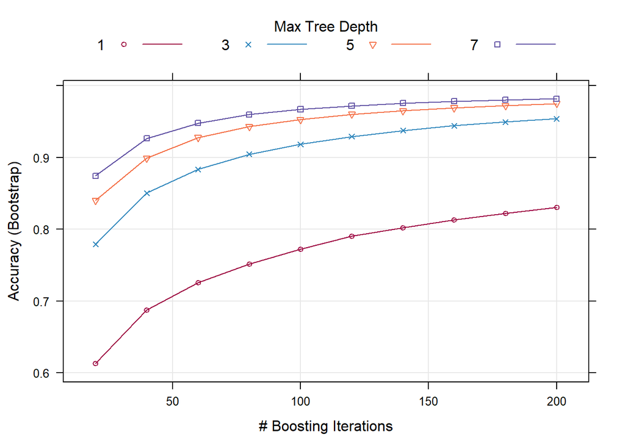

```r
trellis.par.set(caretTheme())
plot(fitGbm)
```

GBM is computationally expensive, but it is accurate. We have not reached maximum accuracy, as we can see on upper plot. Probably, it is possible to improve accuracy, increasing number of interactions and number of trees, and also we should check results on cross-validation set to prevent overfitting.

### Random Forest

```r
set.seed(858523)
rfGrid<-expand.grid(.mtry=c(1:16))
fitRF<-train(classe~., data=trainset2, method="rf", verbose=F, tuneGrid=rfGrid)
confusionMatrix(predict(fitRF, newdata=crossval), crossval$classe)
```

```
## Confusion Matrix and Statistics
##
##           Reference
## Prediction    A    B    C    D    E
##          A 1393    6    0    0    0
##          B    2  939    5    0    0
##          C    0    4  846   14    0
##          D    0    0    4  786    1
##          E    0    0    0    4  900
##
## Overall Statistics
##
##                Accuracy : 0.9918
##                  95% CI : (0.9889, 0.9942)
##     No Information Rate : 0.2845
##     P-Value [Acc > NIR] : < 2.2e-16
##
##                   Kappa : 0.9897
##
##  Mcnemar's Test P-Value : NA
##
## Statistics by Class:
##
##                      Class: A Class: B Class: C Class: D Class: E
## Sensitivity            0.9986   0.9895   0.9895   0.9776   0.9989
## Specificity            0.9983   0.9982   0.9956   0.9988   0.9990
## Pos Pred Value         0.9957   0.9926   0.9792   0.9937   0.9956
## Neg Pred Value         0.9994   0.9975   0.9978   0.9956   0.9998
## Prevalence             0.2845   0.1935   0.1743   0.1639   0.1837
## Detection Rate         0.2841   0.1915   0.1725   0.1603   0.1835
## Detection Prevalence   0.2853   0.1929   0.1762   0.1613   0.1843
## Balanced Accuracy      0.9984   0.9938   0.9925   0.9882   0.9989
```

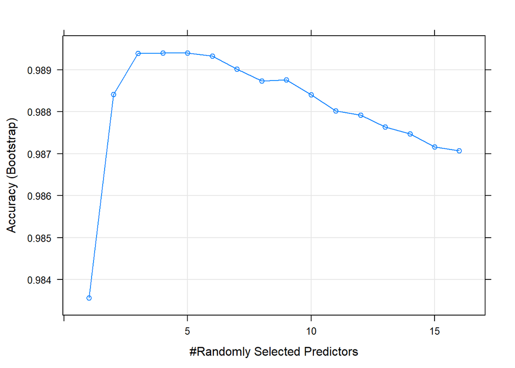

```r
plot(fitRF)
```

Random forest is computationally expensive, and have even higher accuracy than GBM. We can see, than RF has maximum accuracy point with 3-5 predictors, and with increasing number of predictors, accuracy (on training set) is decreasing. We need just several predictors for our predictive algorithm, so it may be more interpretable and computationally fast in compare with other methods.

### Regularized Discriminant Analysis

Our last algorithm would be RDA with default settings:

```r
set.seed(3456220)
fitRDA<-train(classe~., data=trainset2, method="rda", verbose=F)
confusionMatrix(predict(fitRDA, newdata=crossval), crossval$classe)
```

```
## Confusion Matrix and Statistics
##
##           Reference
## Prediction    A    B    C    D    E
##          A 1117   48    3   11    2
##          B   97  761   68   23   70
##          C  142  106  748  180   45
##          D   27    7   35  570   60
##          E   12   27    1   20  724
##
## Overall Statistics
##
##                Accuracy : 0.7993
##                  95% CI : (0.7879, 0.8105)
##     No Information Rate : 0.2845
##     P-Value [Acc > NIR] : < 2.2e-16
##
##                   Kappa : 0.7476
##
##  Mcnemar's Test P-Value : < 2.2e-16
##
## Statistics by Class:
##
##                      Class: A Class: B Class: C Class: D Class: E
## Sensitivity            0.8007   0.8019   0.8749   0.7090   0.8036
## Specificity            0.9818   0.9348   0.8832   0.9685   0.9850
## Pos Pred Value         0.9458   0.7468   0.6126   0.8155   0.9235
## Neg Pred Value         0.9253   0.9516   0.9709   0.9444   0.9570
## Prevalence             0.2845   0.1935   0.1743   0.1639   0.1837
## Detection Rate         0.2278   0.1552   0.1525   0.1162   0.1476
## Detection Prevalence   0.2408   0.2078   0.2490   0.1425   0.1599
## Balanced Accuracy      0.8912   0.8683   0.8790   0.8387   0.8943
```

We can see, that RDA has much lower accuracy, this is not proper method for this case.

## SUMMARY

We have explored some machine learning algorithms for predicting manner of barbell lifts. Our best algorithm on cross-validation set is Random Forest with 0.9918 accuracy. We don’t know “right answers” for our test set (even if we tune model for 100% accuracy on cross-validation set there should be some uncertainty), but our estimated prediction accuracy should be close to this number. We can calculate estimated probability for getting 100% on automated grader as:

```r
0.9918^20
```

```
## [1] 0.8481684
```

This is high enough for our purposes, so we select Random Forest algorithm as our final model.